# Final Project

Aksheytha Chelikavada

2023-05-14

# 1 DATA PREPARATION

## Part 1.1

```r
library(dplyr)
saipe_raw <- read.csv("C:\\Users\\akshe\\Downloads\\SAIPE_04-14-2023.csv")

saipe_mn <- saipe_raw %>% filter(!(Name == "Minnesota")) %>% filter(!(Name == "United States"))%>% select(Year, FIPS = ID, Name, Pop = Poverty.Universe, Poverty = Number.in.Poverty)
```

Find the largest county, and the nine largest counties by population

```r
largest_county_pop <- saipe_mn %>% group_by(FIPS, Name) %>% summarize(Pop = mean(Pop, na.rm = TRUE)) %>%  arrange(desc(Pop)) %>% head(n = 9)
largest_county_pop
```

| FIPS | Name | Pop |
| --- | --- | --- |
| 27053 | Hennepin County | 1152894.8 |
| 27123 | Ramsey County | 503860.2 |
| 27037 | Dakota County | 395766.3 |
| 27003 | Anoka County | 329222.4 |
| 27163 | Washington County | 232358.9 |
| 27137 | St. Louis County | 190716.9 |
| 27145 | Stearns County | 141531.2 |
| 27109 | Olmsted County | 141012.9 |
| 27139 | Scott County | 126144.7 |

```r
FIPSvalue <- saipe_mn %>% group_by(FIPS, Name) %>% summarize(Pop = mean(Pop, na.rm = TRUE)) %>%  arrange(desc(Pop)) %>% head(n = 9) %>% pull(FIPS)
biggest_county <- saipe_mn %>% group_by(FIPS, Name) %>% summarize(Pop = mean(Pop, na.rm = TRUE)) %>%  arrange(desc(Pop)) %>% head(n = 1)
biggest_county
```

| FIPS | Name | Pop |
| --- | --- | --- |
| 27053 | Hennepin County | 1152895 |

Make a time plot showing the number in poverty for each of the nine largest counties

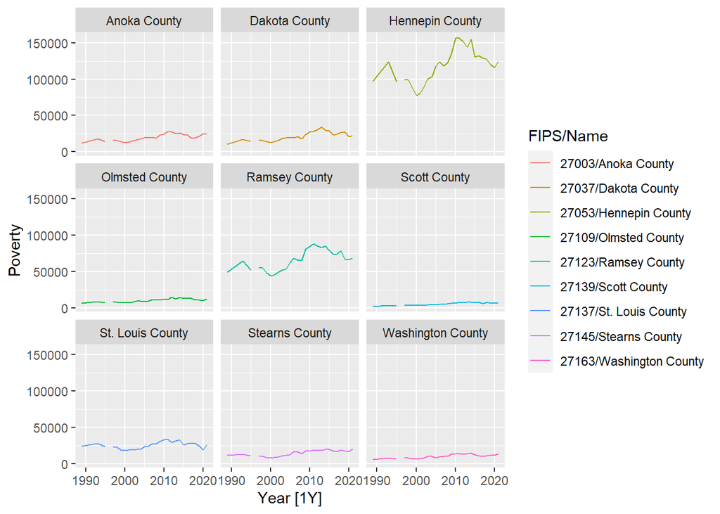

```r
library(dplyr)
library(ggplot2)
library(gtrendsR)
library(tsibble)
library(feasts)

saipe_mn_tsibble <- saipe_mn %>% as_tsibble(index = Year, key = c(FIPS, Name)) %>% filter(FIPS %in% FIPSvalue)

saipe_mn_tsibble  %>% autoplot(Poverty) + facet_wrap(vars(Name))
```

## Part 1.2

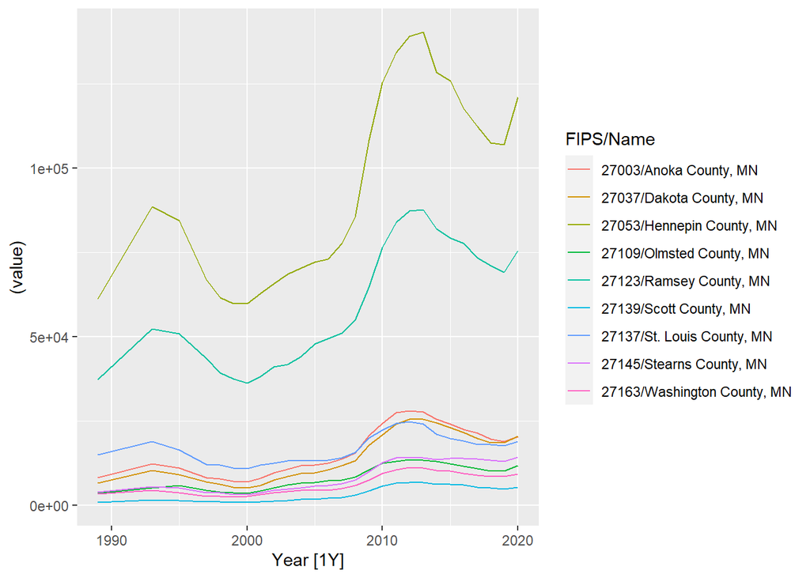

```r
library(stringr)
library(lubridate)
library(tidyverse)
library(readr)

cntySnap_raw <- read.csv("C:\\Users\\akshe\\Downloads\\cntysnap.csv",skip = 4, sep ="," )

mnCnty <- cntySnap_raw %>% filter(grepl("MN", Name))

code_mnCnty <- mnCnty %>% mutate(FIPS = paste("27",str_pad(County.FIPS.code, width = 3, pad = "0"), sep = ""))

pivot_code_mnCnty <- code_mnCnty %>% pivot_longer(cols = starts_with("Jul")) %>% mutate(value = as.integer(str_remove(value, ","))) %>% filter(FIPS %in% FIPSvalue) %>% mutate(Year = year(yearmonth(name))) %>% as_tsibble(index = Year, key = c(FIPS, Name))

pivot_code_mnCnty  %>% ggplot2::autoplot((value))
```

## Part 1.3

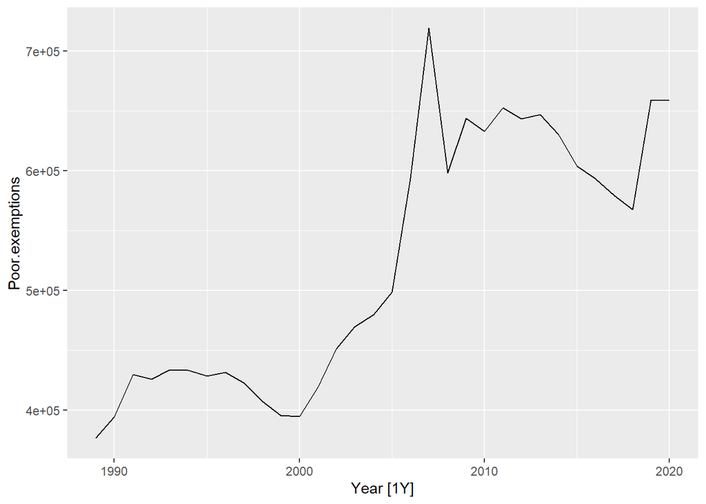

```r
raw_irs <- read.csv("C:\\Users\\akshe\\Downloads\\irs.csv", skip = 4)

ts_irs <- raw_irs %>% filter(Name == "Minnesota") %>% mutate(Poor.exemptions = as.integer(str_remove(Poor.exemptions, ","))) %>% as_tsibble(index = Year)

ts_irs %>% autoplot(Poor.exemptions)
```

## Part 1.4

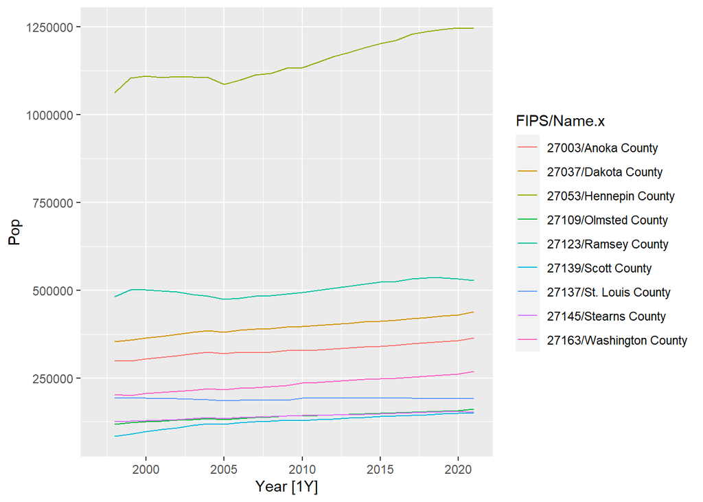

```r
library(lubridate)
library(tidyverse)
library(readr)

join_ts_irs <- raw_irs %>% filter(Name == "Minnesota") %>% dplyr::select(Year, Poor.exemptions) %>% mutate(Poor.exemptions = as.integer(str_remove(Poor.exemptions, ","))) %>% as_tsibble(index = Year)

pivot_code_mnCnty_all <- code_mnCnty %>% pivot_longer(cols = starts_with("Jul")) %>% mutate(value = as.integer(str_remove(value, ","))) %>%  mutate(Year = year(yearmonth(name))) %>% as_tsibble(index = Year, key = c(FIPS, Name))

join_mnCnty_all <- pivot_code_mnCnty_all %>% dplyr::select(FIPS, value, Year)

new_join_mnCnty_all <- join_mnCnty_all %>% mutate(FIPS = as.integer(FIPS))

saipe_mn_join1 <- left_join(saipe_mn, new_join_mnCnty_all, by=c('Year','FIPS'))

final_join_ts <- left_join(saipe_mn_join1, join_ts_irs, by = 'Year') %>% filter(Year >= 1997) %>% as_tsibble(index = Year, key = c(FIPS, Name.x))

graph_final_ts <- final_join_ts %>% filter(FIPS %in% FIPSvalue)

graph_final_ts %>% autoplot(Pop)
```

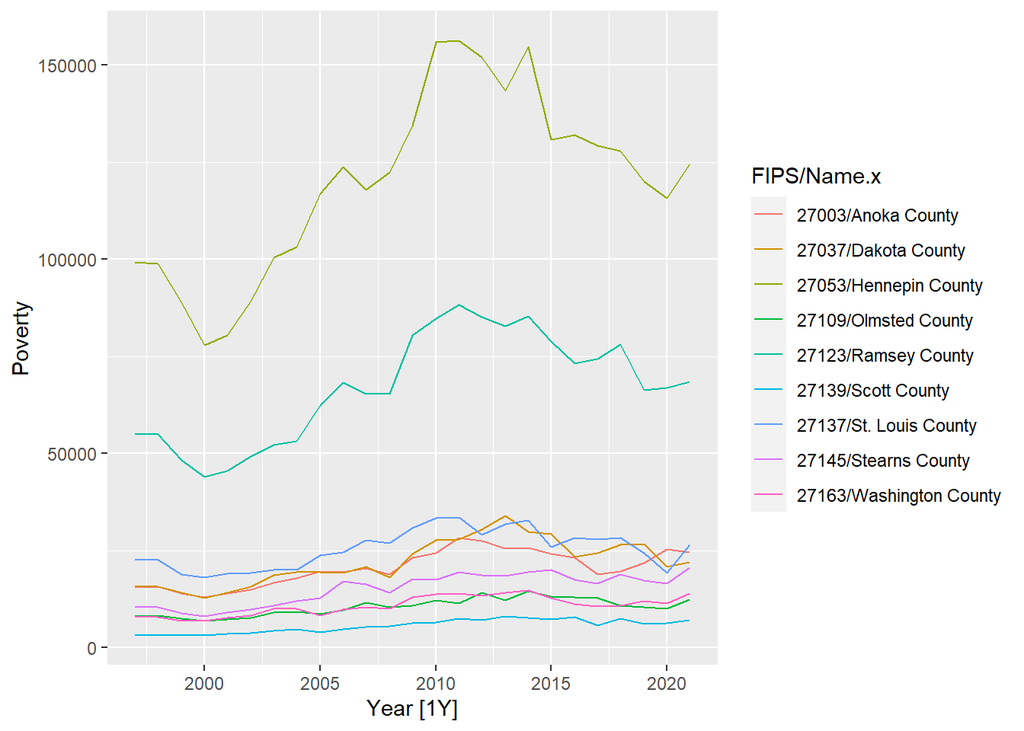

```r
graph_final_ts %>% autoplot(Poverty)
```

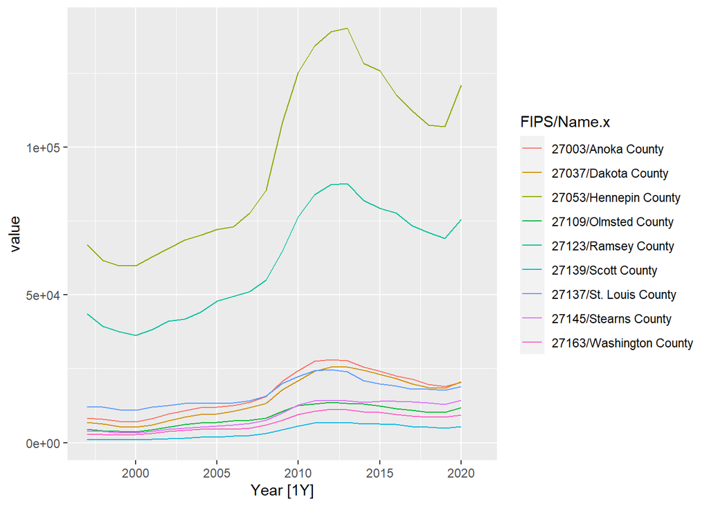

```r
graph_final_ts %>% autoplot(value)
```

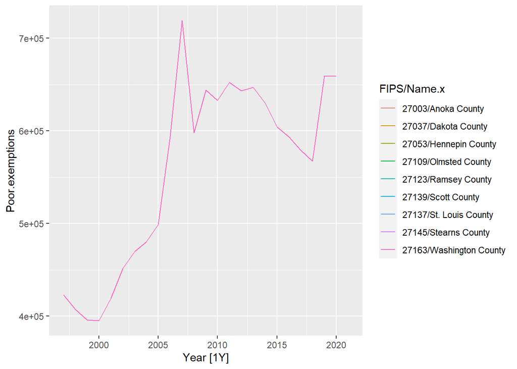

```r
graph_final_ts %>% autoplot(Poor.exemptions)
```

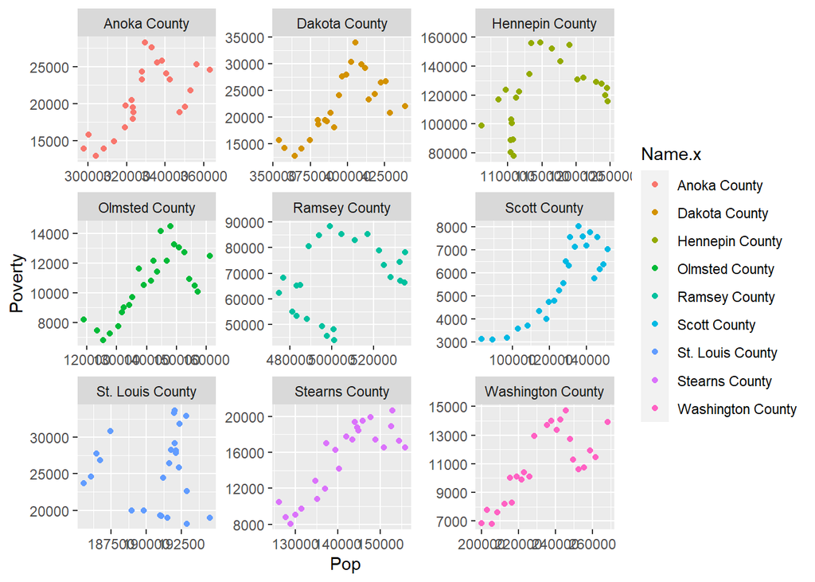

```r
graph_final_ts %>% as_tibble() %>% ggplot(aes(x = Pop, y = Poverty, color = Name.x)) + geom_point() + facet_wrap(vars(Name.x), scales = "free")
```

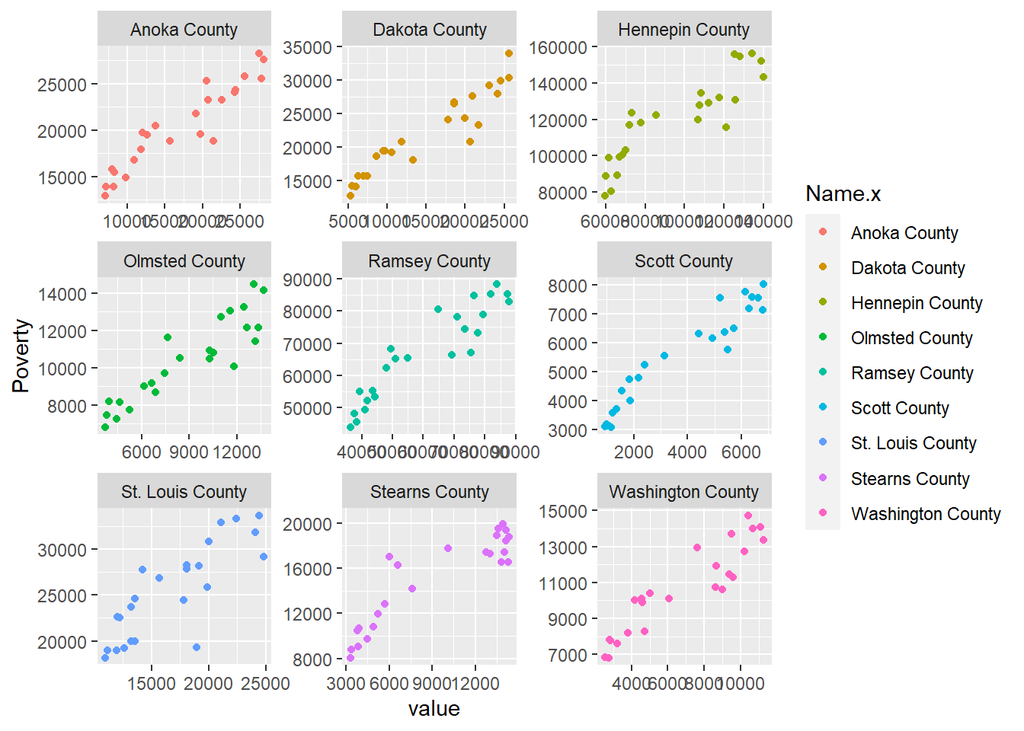

```r
graph_final_ts %>% as_tibble() %>% ggplot(aes(x = value, y = Poverty, color = Name.x)) + geom_point() + facet_wrap(vars(Name.x), scales = "free")
```

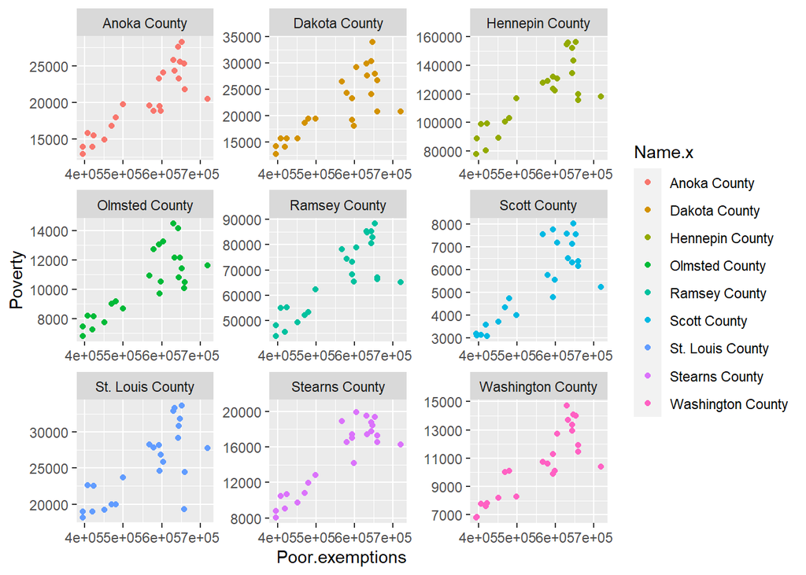

```r
graph_final_ts %>% as_tibble() %>% ggplot(aes(x = Poor.exemptions, y = Poverty, color = Name.x)) + geom_point() + facet_wrap(vars(Name.x), scales = "free")
```

# 2 Linear Models

## Part 2.1

```r
library(forecast)
library(dplyr)
library(lubridate)
library(fpp3)
test_final_ts <-  final_join_ts %>% model(t1 = TSLM(log(Poverty) ~ log(Pop)),
                                           t2 = TSLM(log(Poverty) ~ log(value)),
                                           t3 = TSLM(log(Poverty) ~ log(Poor.exemptions)),
                                           t4 = TSLM(log(Poverty) ~ log(Poor.exemptions)+log(value)),
                                           t5 = TSLM(log(Poverty) ~ log(Poor.exemptions)+log(Pop)),
                                           t6 = TSLM(log(Poverty) ~ log(Pop)+ log(value)),
                                           t7 = TSLM(log(Poverty) ~ log(Pop) + log(value) + log(Poor.exemptions)))


glance(test_final_ts) |> group_by(.model) %>% summarise(CV = sum(CV), AIC = sum(AIC)) %>% arrange(CV, AIC) |>
  dplyr::select(.model,CV, AIC)
```

| .model | CV | AIC |
| --- | --- | --- |
| t6 | 1.026588 | -8915.156 |
| t7 | 1.058490 | -8948.438 |
| t2 | 1.089927 | -9094.049 |
| t4 | 1.160378 | -9076.633 |
| t5 | 1.418251 | -8325.862 |
| t3 | 1.421167 | -8548.495 |
| t1 | 1.798562 | -8143.715 |

The model that does the best across all counties is t6 which is TSLM(log(Poverty) ~ log(Pop)+ log(value)). This best model includes poverty, population, and value.

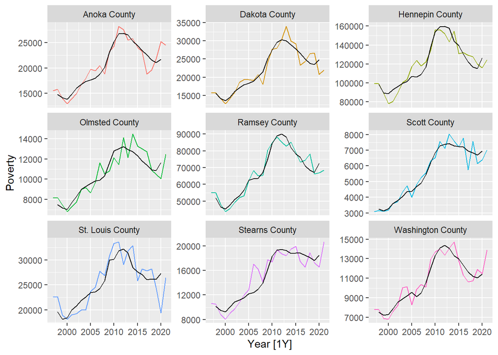

```r
bestModel <- final_join_ts %>% model(TSLM(log(Poverty) ~ log(Pop)+ log(value)))

bestModel %>% filter(FIPS %in% FIPSvalue) %>% augment() %>% autoplot(Poverty) + geom_line(aes(y = .fitted), color = "Black") + facet_wrap(vars(Name.x), scales = "free_y") + theme(legend.position = "none")
```

## Part 2.2

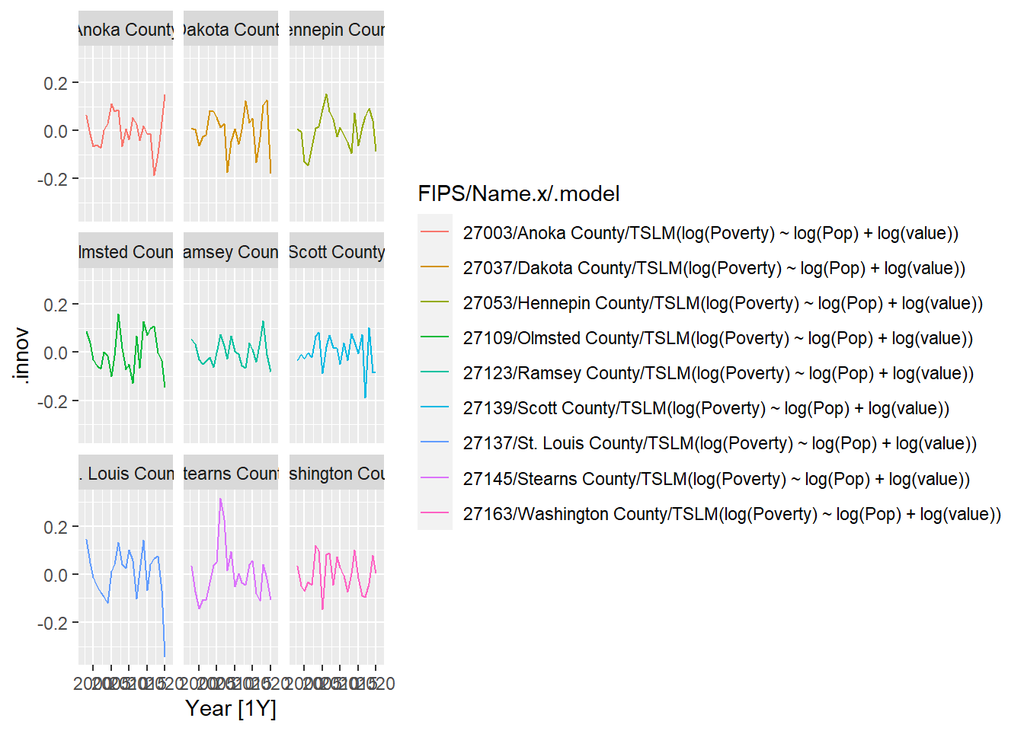

```r
plotRes<- bestModel %>% filter(FIPS %in% FIPSvalue) %>% augment()

autoplot(plotRes, .innov) + facet_wrap(vars(Name.x))
```

```r
allCountyFIPS <- bestModel %>% pull(FIPS)

bestModel %>% augment() %>% features(.innov, ljung_box) %>% arrange(lb_pvalue)
```

| FIPS | Name.x | .model | lb_stat | lb_pvalue |
| --- | --- | --- | --- | --- |
| 27097 | Morrison County | TSLM(log(Poverty) ~ log(Pop) + log(value)) | 10.989316593 | 0.000916386 |
| 27145 | Stearns County | TSLM(log(Poverty) ~ log(Pop) + log(value)) | 6.609837735 | 0.010141690 |
| 27053 | Hennepin County | TSLM(log(Poverty) ~ log(Pop) + log(value)) | 5.587924700 | 0.018084710 |
| 27049 | Goodhue County | TSLM(log(Poverty) ~ log(Pop) + log(value)) | 5.210572361 | 0.022449943 |
| 27015 | Brown County | TSLM(log(Poverty) ~ log(Pop) + log(value)) | 4.783146583 | 0.028739560 |
| 27149 | Stevens County | TSLM(log(Poverty) ~ log(Pop) + log(value)) | 4.730488676 | 0.029632465 |
| 27059 | Isanti County | TSLM(log(Poverty) ~ log(Pop) + log(value)) | 4.602173125 | 0.031931457 |
| 27083 | Lyon County | TSLM(log(Poverty) ~ log(Pop) + log(value)) | 4.508143346 | 0.033733839 |
| 27139 | Scott County | TSLM(log(Poverty) ~ log(Pop) + log(value)) | 3.679300467 | 0.055091960 |
| 27107 | Norman County | TSLM(log(Poverty) ~ log(Pop) + log(value)) | 3.347088953 | 0.067323974 |

[output cut: 77 more lines]

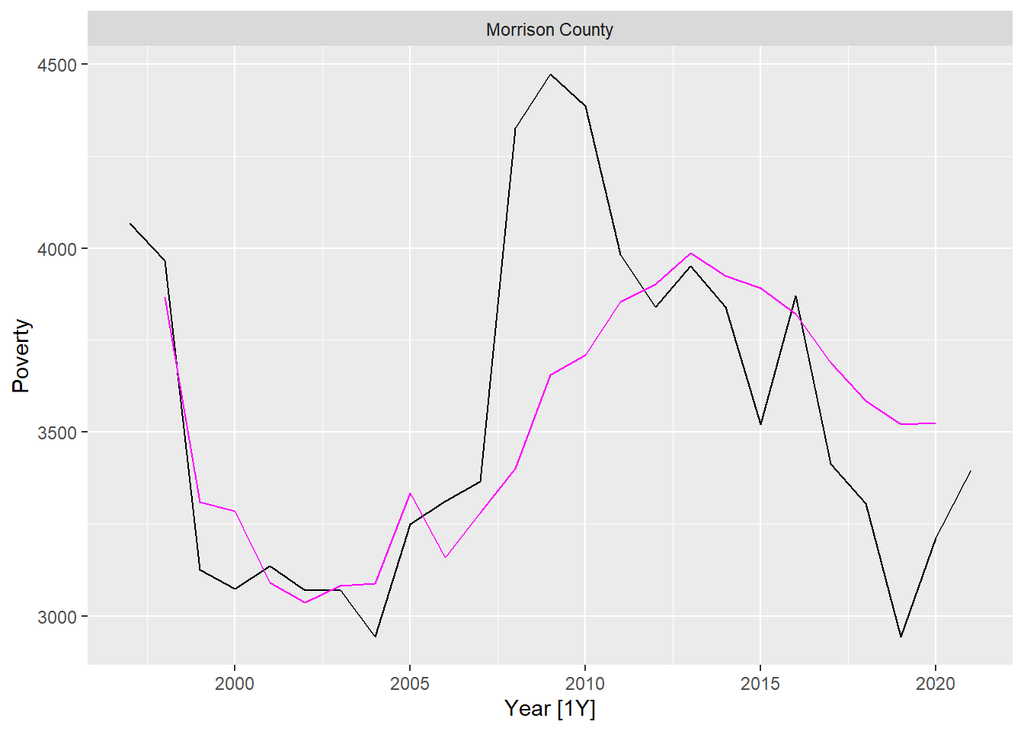

```r
bestModel %>% filter(FIPS == 27097) %>% augment() %>% autoplot(Poverty) + geom_line(aes(y = .fitted), color = "Magenta") + facet_wrap(vars(Name.x), scales = "free") + theme(legend.position = "none")
```

# 3 Stochastic Models

## Part 3.1

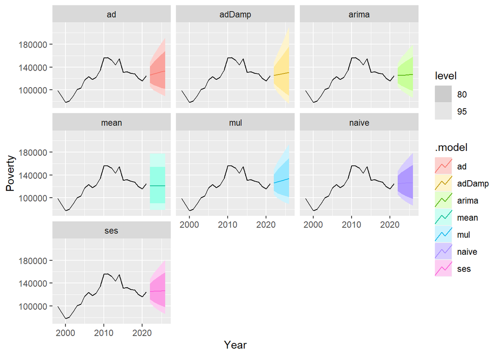

```r
saipe_hen <- saipe_mn %>% filter(!(Year %in% c(1996, 1989, 1993, 1995, 1997))) %>% as_tsibble(index = Year, key = c(FIPS, Name)) %>% filter(FIPS == 27053)

hen_model <-  saipe_hen %>% model(naive = NAIVE(log(Poverty)),
                                           mean = MEAN(log(Poverty)),
                                           ses = ETS(log(Poverty) ~ error("A") + trend("N") + season("N")),
                                           adDamp = ETS(log((Poverty)) ~ error('A') + trend('Ad')),
                                           ad = ETS(log((Poverty)) ~ error('A') + trend('A')),
                                           mul = ETS(log((Poverty)) ~ error('M') + trend('A')),
                                           arima = ARIMA(log(Poverty)))

hen_model  %>% forecast(h = '5 year') %>%  autoplot(saipe_hen) + facet_wrap(.~.model)
```

```r
glance(hen_model)
```

| FIPS | Name | .model | sigma2 | log_lik | AIC | AICc | BIC | MSE | AMSE | MAE | ar_roots | ma_roots |
| --- | --- | --- | --- | --- | --- | --- | --- | --- | --- | --- | --- | --- |
| 27053 | Hennepin County | naive | 7.118151e-03 | NA | NA | NA | NA | NA | NA | NA |  |  |
| 27053 | Hennepin County | mean | 4.123677e-02 | NA | NA | NA | NA | NA | NA | NA |  |  |
| 27053 | Hennepin County | ses | 7.224379e-03 | 22.07102 | -38.14204 | -36.94204 | -34.60788 | 0.006622347 | 0.01710735 | 0.065837173 |  |  |
| 27053 | Hennepin County | adDamp | 7.939057e-03 | 22.69826 | -33.39652 | -28.45535 | -26.32820 | 0.006285087 | 0.01763162 | 0.064994508 |  |  |
| 27053 | Hennepin County | ad | 7.912110e-03 | 22.12354 | -34.24708 | -30.91375 | -28.35681 | 0.006593425 | 0.01652444 | 0.065862028 |  |  |
| 27053 | Hennepin County | mul | 5.755145e-05 | 22.21374 | -34.42747 | -31.09414 | -28.53720 | 0.006529722 | 0.01654758 | 0.005597185 |  |  |
| 27053 | Hennepin County | arima | 6.915717e-03 | 24.57451 | -47.14901 | -46.95854 | -46.01352 | NA | NA | NA |  |  |

The ARIMA model works the best.

## Part 3.2

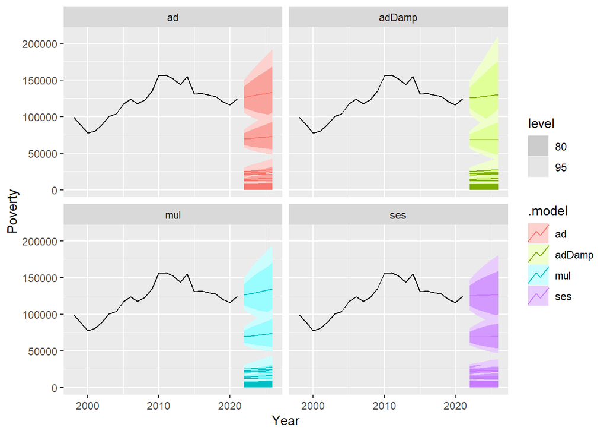

```r
saipe_all <- saipe_mn %>% filter(!(Year %in% c(1996, 1989, 1993, 1995, 1997))) %>% as_tsibble(index = Year, key = c(FIPS, Name))

all_model <-  saipe_all %>% model(
                                           ses = ETS(log(Poverty) ~ error("A") + trend("N") + season("N")),
                                           adDamp = ETS(log((Poverty)) ~ error('A') + trend('Ad')),
                                           ad = ETS(log((Poverty)) ~ error('A') + trend('A')),
                                           mul = ETS(log((Poverty)) ~ error('M') + trend('A')))


all_model  %>% forecast(h = '5 year') %>%  autoplot(saipe_hen) + facet_wrap(.~.model)
```

```r
glance(all_model) |> group_by(.model) %>% summarise(AIC = sum(AIC)) %>% arrange(AIC) |>
  dplyr::select(.model, AIC)
```

| .model | AIC |
| --- | --- |
| ses | -2096.389 |
| mul | -1808.956 |
| ad | -1792.932 |
| adDamp | -1691.114 |

The ses model did the best compared to the rest of the models. The reason why I chose ses is because it has the lowest AIC score

## Part 3.3

```r
arimaFit <- saipe_all %>% model(ARIMA(log(Poverty)))
arimaFit
```

| FIPS | Name | ARIMA(log(Poverty)) |
| --- | --- | --- |
| 27001 | Aitkin County |  |
| 27003 | Anoka County |  |
| 27005 | Becker County |  |
| 27007 | Beltrami County |  |
| 27009 | Benton County |  |
| 27011 | Big Stone County |  |
| 27013 | Blue Earth County |  |
| 27015 | Brown County |  |
| 27017 | Carlton County |  |
| 27019 | Carver County |  |

[output cut: 77 more lines]

```r
arimaFits <- saipe_all %>% model(fit100 = ARIMA(log(Poverty) ~ 1 + pdq(1,0,0)),
                                 fit001 = ARIMA(log(Poverty) ~ 1 + pdq(0,0,1)))

glance(arimaFits) |> group_by(.model) %>% summarise(AIC = sum(AIC)) %>% arrange(AIC) |>
  dplyr::select(.model, AIC)
```

| .model | AIC |
| --- | --- |
| fit100 | -2890.767 |
| fit001 | -2430.380 |

(1,0,0) with mean and (0,0,1) with mean are the most common. from the data, (1,0,0) did the best.

## Part 3.4

```r
saipe_all_tr <- saipe_all |>
  stretch_tsibble(.init = 15, .step = 1)

fit_mn <- saipe_all_tr |>
  model(fit100 = ARIMA(log(Poverty) ~ 1 + pdq(1,0,0)),
        ses = ETS(log(Poverty) ~ error("A") + trend("N") + season("N")))
#{r crossValidate, cache = TRUE}
```

```r
acc <- fit_mn  %>% forecast(h = 5) %>% fabletools::accuracy(data = saipe_all)
acc %>% group_by(.model) %>% summarize(sqrt(sum(RMSE*RMSE)))
```

| .model | sqrt(sum(RMSE * RMSE)) |
| --- | --- |
| fit100 | 14767.56 |
| ses | 21093.26 |

fit100 is the winning model